# assignment_1

**NB**: We have experienced that sometimes folium maps won't render in the notebook. Therefore we have also attached a HTML copy of the notebook where we know that the maps will render. Please see that file if you have trouble viewing the maps in this notebook.

```python
%matplotlib inline
import folium
from folium import plugins
import matplotlib.pyplot as plt
import numpy as np
import pandas as pd
from scipy import stats
import seaborn as sns
from sklearn import tree
from sklearn.ensemble import RandomForestClassifier
```

Load dataset and do preprocessing.

```python
data = pd.read_csv('incident_reports.csv', parse_dates=['Date'])
```

```python
def getHour(time):
    return int(time.split(':')[0])

def getMinute(time):
    return int(time.split(':')[1])

data['Hour'] = data.Time.map(getHour)
data['Minute'] = data.Time.map(getMinute)
data.DayOfWeek = pd.Categorical(data.DayOfWeek)
data["Day"] = data.DayOfWeek.cat.codes
data.PdDistrict = pd.Categorical(data.PdDistrict)
data["Dst"] = data.PdDistrict.cat.codes
data['Month'] = data.Date.dt.month
data['Year'] = data.Date.dt.year
```

# Part 1: Temporal evolution of focus crimes

**Police chief Suneman is interested in the temporal development of only a subset of categories, the so-called focus crimes. Those categories are listed below (for convenient copy-paste action). Create bar-charts displaying the year-by-year development of each of these categories across the years 2003-2017.**

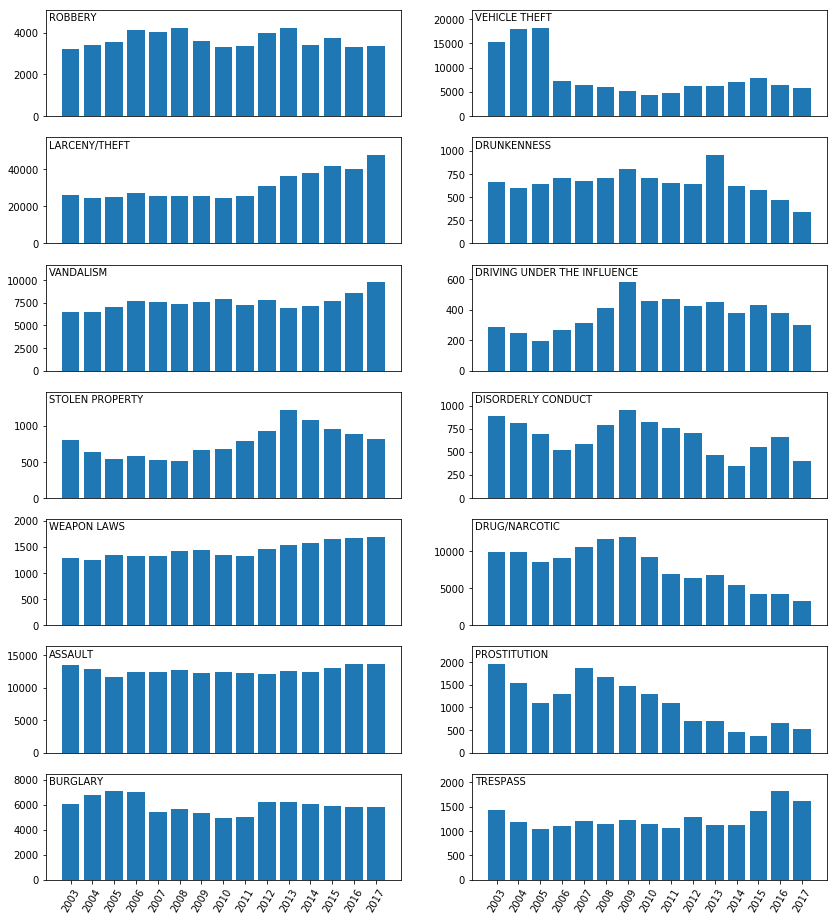

```python
focus_crimes = set (['WEAPON LAWS', 'PROSTITUTION', 'DRIVING UNDER THE INFLUENCE', 'ROBBERY', 'BURGLARY', 'ASSAULT', 'DRUNKENNESS', 'DRUG/NARCOTIC', 'TRESPASS', 'LARCENY/THEFT', 'VANDALISM', 'VEHICLE THEFT', 'STOLEN PROPERTY', 'DISORDERLY CONDUCT'])

fig = plt.figure(figsize=(14, 16))
pos = np.arange(15)

for i, crime in enumerate(focus_crimes):
    ax = plt.subplot(7, 2, i + 1)
    ax.text(.01, .9, crime, transform=ax.transAxes)
    ax.margins(y=0.2)

    displayed = data[data["Category"] == crime].groupby(data.Date.dt.year).size().iloc[:15]
    plt.bar(pos, displayed, align='center')

    if (i is 12) or (i is 13):
        plt.xticks(pos, displayed.keys(), rotation=60)
    else:
        plt.xticks([])

plt.show()
```

# Part 2: Visualizing geo-data

**Select a couple of months of data (for example, June-July 2016) for 'DRUG/NARCOTIC' and the same couple of month for 'LARCENY/THEFT'. Note: There is an issue with folium and plotting lots of points, so if you have trouble plotting simply select a shorter time period; you should be able to plot a couple of thousand points.**

Define the time period to work with. In order to overcome folium limitations on how many points can be plotted on a scatter plot, we decieded to focus on crimes that took place in the first 10 days of June 2017.

```python
YEAR = 2017
MONTH = [6]
BEFORE_DAY = 10
```

Define a function to filter the data from the original dataset:

```python
def filter_crimes(data, category, year, month, before_day):
    crimes = data[(data['Category'] == category)]
    crimes = crimes[(crimes['Date'].dt.year == year) & (crimes['Date'].dt.month.isin(month)) & (crimes['Date'].dt.day < before_day)]
    return crimes
```

**Draw a little circle for each arrest in the category 'DRUG/NARCOTIC' for your time period. We can call this a kind of visualization a scatter plot**

Filter data from the original dataset:

```python
drug_crimes = filter_crimes(data, 'DRUG/NARCOTIC', YEAR, MONTH, BEFORE_DAY)
print(f'No. of drug crimes: {len(drug_crimes)}')
```

```
No. of drug crimes: 61
```

Construct the map:

```python
m = folium.Map([37.77919, -122.41914], zoom_start=13)
for index, row in drug_crimes.iterrows():
    folium.CircleMarker([row['Y'], row['X']],
                        popup=str(row['IncidntNum']),
                        radius=5,
                        color="blue",
                       ).add_to(m)
m
```

[interactive chart not shown]

**Draw a little circle for each arrest in the category 'LARCENY/THEFT' for the time period.**

Filter data from the original dataset:

```python
theft_crimes = filter_crimes(data, 'LARCENY/THEFT', YEAR, MONTH, BEFORE_DAY)
print(f'No. of theft crimes: {len(theft_crimes)}')
```

```
No. of theft crimes: 1126
```

Construct the map:

```python
m = folium.Map([37.77919, -122.41914], zoom_start=13)
for index, row in theft_crimes.iterrows():
    folium.CircleMarker([row['Y'], row['X']],
                        popup=str(row['IncidntNum']),
                        radius=5,
                        color="red",
                       ).add_to(m)
m
```

[interactive chart not shown]

**Now, let's play with heatmaps.**

Define function to construct the heatmap. A specific type of tiles has been selected to show a black and white map to highlight the colors of the data shown on top of it.

```python
def getHeatMap(data):
    m = folium.Map([37.77919, -122.41914], tiles='stamentoner', zoom_start=13)
    coordinates = data[['Y', 'X']].values
    m.add_child(plugins.HeatMap(coordinates, radius=15))
    return m
```

**Create a heatmap of all arrests for 'DRUG/NARCOTIC' during June-July 2016 (with the heatmap you should be able to use the full period). Play with parameters to get plots you like**

```python
drug_crimes = filter_crimes(data, 'DRUG/NARCOTIC', 2016, [6,7], 32)
```

```python
getHeatMap(drug_crimes)
```

[interactive chart not shown]

**Create a heatmap of all arrests for 'LARCENY/THEFT' during June-July 2016 (with the heatmap you should be able to use the full period).**

```python
theft_crimes = filter_crimes(data, 'LARCENY/THEFT', 2016, [6,7], 32)
```

```python
getHeatMap(theft_crimes)
```

[interactive chart not shown]

**Comment on the differences. What can you see using the scatter-plots that you can't see using the heatmaps? And vice versa: what does the heatmaps help you see that's difficult to distinguish in the scatter-plots?**

The drugs/narcotic crime is very much limited to a specific area and has few high density places within that. The larceny/theft crime, on the other hand, covers a wider area and has more high density regions. A couple in the same area as the drugs/narcotic one, and others more north and west. From the heatmap, it looks like theft is a more common crime and affecting a wider area of San Francisco, whereas the drug crimes are less and limited to specific places.

Heatmaps are very intiutive tool to detect density differences in different areas and to get a direct visual feedback on how vast a crime affected area is and where the hot points are. This cannot be achieved with the same level of intuitiveness with scatter plots. Scatter plots, on the other hand, give a realistic idea of how many occurrences happened in each zone by plotting each occurrence. This allows to have a high degree of details and fidelity over the position and amount of crimes happened. Heatmaps however hide this sort of details when plotting densities.

Scatter plot:

- **Pros:**
  - This plot allows to see all the occurrences spread on the plotted area. This means that it gives a realistic idea of how many occurrences happened in each zone.
- **Cons:**
  - It is difficult to get a precise idea of how the distribution and concentration look like, over the area. High density areas tend to look like an agglomerate of color, because of all the circles in the same area. It is though difficult to distinguish the different agglomerate in terms of which ones are more dense than others.

Heatmaps:

- **Pros:**
  - These maps highlight the concentration of crimes in specific areas and the distribution of the different densities over the map. It is then easy to compare the differents zones' densities just by comparing their color.
- **Cons:**
  - Hide away the real number of occurrences. It is not easy to determine how many crimes a high density zone contain.

**Comment on the effect on the various parameters for the heatmaps. How do they change the picture?**

From the official documentation, these are the parameter which can be passed to the heatmap:

- data (list of points of the form [lat, lng] or [lat, lng, weight]) – The points you want to plot. You can also provide a numpy.array of shape (n,2) or (n,3).
- name (string, default None) – The name of the Layer, as it will appear in LayerControls.
- min_opacity (default 1.) – The minimum opacity the heat will start at.
- max_zoom (default 18) – Zoom level where the points reach maximum intensity (as intensity scales with zoom), equals maxZoom of the map by default
- max_val (float, default 1.) – Maximum point intensity
- radius (int, default 25) – Radius of each “point” of the heatmap
- blur (int, default 15) – Amount of blur
- gradient (dict, default None) – Color gradient config. e.g. {0.4: ‘blue’, 0.65: ‘lime’, 1: ‘red’}
- overlay (bool, default True) – Adds the layer as an optional overlay (True) or the base layer (False).
- control (bool, default True) – Whether the Layer will be included in LayerControls.
- show (bool, default True) – Whether the layer will be shown on opening (only for overlays).

We will not comment on the effect of all the parameters since many of them appear to be self-explanatory. Instead we have chosen to comment on the following parameters:

- radius
- blur
- min_opacity

#### Radius and Blur parameter

By reducing both the radius and the blurriness, it is possible to achieve a heatmap which recalls the scatter plot one: with sharp circles for each occurrence. The color of the circles, however, still reppresent the concentration of crimes, allowing us to have more information than a scatter plot.

```python
def getHeatMap(data):
    m = folium.Map([37.77919, -122.41914], tiles='stamentoner', zoom_start=13)
    coordinates = data[['Y', 'X']].values
    m.add_child(plugins.HeatMap(coordinates, radius=10, blur=0.1))
    return m
```

```python
drug_crimes = filter_crimes(data, 'DRUG/NARCOTIC', 2016, [6,7], 32)
getHeatMap(drug_crimes)
```

[interactive chart not shown]

#### Blur parameter

This parameter determines how blurry the circles will be on the map. Decreasing it allows to draw sharper circles. By reducing the blurrines, the achieved effect is to a more precise reppresentation of the occurrences, more similar to a scatter plot.

```python
def getHeatMap(data):
    m = folium.Map([37.77919, -122.41914], tiles='stamentoner', zoom_start=13)
    coordinates = data[['Y', 'X']].values
    m.add_child(plugins.HeatMap(coordinates, radius=10, blur=10))
    return m
```

```python
drug_crimes = filter_crimes(data, 'DRUG/NARCOTIC', 2016, [6,7], 32)
getHeatMap(drug_crimes)
```

[interactive chart not shown]

#### Min_opacity parameter

This parameter determines how transparent the heat map will be at minimum. It may help in making the heat map look less cluttered.

```python
def getHeatMap(data):
    m = folium.Map([37.77919, -122.41914], tiles='stamentoner', zoom_start=13)
    coordinates = data[['Y', 'X']].values
    m.add_child(plugins.HeatMap(coordinates, min_opacity=0.01))
    return m
```

```python
drug_crimes = filter_crimes(data, 'DRUG/NARCOTIC', 2016, [6,7], 32)
getHeatMap(drug_crimes)
```

[interactive chart not shown]

# Part 3: Some single variable plots

**First create a jitter-plot (that is, code up something like Figure 2-1 from DAOST from scratch), but based on SF Police data. My hunch from inspecting the file is that the police-folks might be a little bit lazy in noting down the exact time down to the second. So choose a crime-type and a suitable time interval (somewhere between a month and 6 months depending on the crime-type) and create a jitter plot of the arrest times during a single hour (e.g. 13-14).**

We have chosen to focus on assaults in January to May between 13 and 14 of each day.

```python
assaults = data[data['Category'] == 'ASSAULT']
assaults_filtered = assaults[(assaults.Date.dt.month < 6) & (assaults.Hour == 13)]
assaults_by_minute = assaults_filtered.groupby('Minute')['IncidntNum'].count()
```

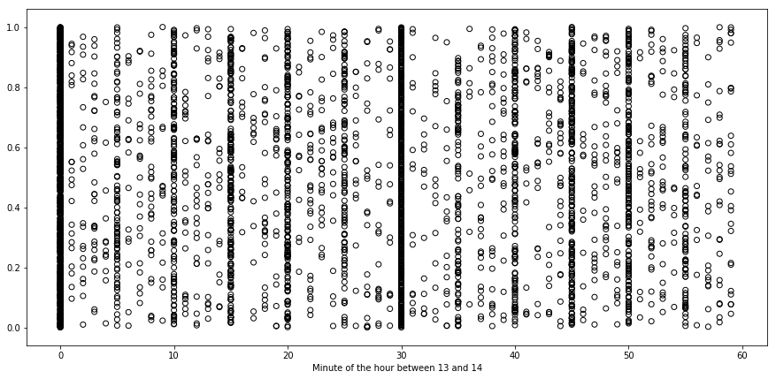

```python
x_spread = 0
y_spread = 1
plt.figure(figsize=(15,7))
for i in range(60):
    x_noise = np.random.rand(assaults_by_minute[i])
    y_noise = np.random.rand(assaults_by_minute[i])
    x = i + x_noise * (2 * x_spread) - x_spread
    y = y_noise * y_spread
    plt.scatter(x, y, marker='o', edgecolors='black', facecolors='none')
plt.xlabel('Minute of the hour between 13 and 14')
plt.show()
```

We see that assaults are mostly reported every 5th and 10th minute. Especially the 0th and 30th minute marks seem to have a high concentration of incidents. Indeed the hunch holds true for the selected date and time interval. It therefore appears that the hunch is correct.

**Now it's time for histograms. We will now create two versions of Figure 2-2.**

**Pick two crime-types with different geographical patterns and a suitable time-interval for each (you want between 1000 and 10000 points in your histogram)**

We have selected drug/narcotics and prostitution throughout January to May and between midnight and 7 in the morning.

```python
filtered = data[(data.Date.dt.month < 6) & ((data.Hour > 0) & (data.Hour < 7))]
drug = filtered[filtered['Category'] == 'DRUG/NARCOTIC']
prost = filtered[filtered['Category'] == 'PROSTITUTION']
```

Let's check that each crime-type has between 1000 and 10000 points in the specified time-interval.

```python
print(f'No. of drugs/narcotics incidents: {len(drug)}')
print(f'No. of prostitution incidents: {len(prost)}')
```

```
No. of drugs/narcotics incidents: 3580
No. of prostitution incidents: 1644
```

**Then take the latitude part of the GPS coordinates for each crime and bin the latitudes so that you have around 50 bins across the city of SF. You can use your favorite method for binning. I like numpy.histogram -- that gives you the counts and then you do your own plotting.**

```python
def histogram(series, max_val=None, min_val=None, no_of_bins=50, **kwargs):
    if max_val is None:
        max_val = series.max()
    if min_val is None:
        min_val = series.min()
    bins = np.linspace(min_val, max_val, no_of_bins)
    plt.hist(series, bins=bins, histtype='step', **kwargs)
```

We will plot the histograms together to compare the lattitudes of the two crime-types.

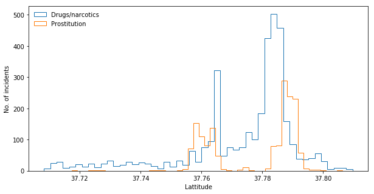

```python
plt.figure(figsize=(10, 5))
histogram(drug.Y, label='Drugs/narcotics')
histogram(prost.Y, label='Prostitution')
plt.legend(frameon=False, loc='upper left')
plt.xlabel('Lattitude')
plt.ylabel('No. of incidents')
plt.show()
```

This shows that drugs/narcotics and prostituion happen close to it each other (when we don't take longitude into account) but they stil don't happen at the exact same locations. Interestingly both distributions seem to have two spikes which suggests that each of the two crime-types mostly happen in two city districts. Another interesting finding is that drug/narcotics has a long tail (to its left) while prostitution is mostly flat outside its spikes. This suggests that drug/narcotics incidents happens throughout the entire city while prostitution is more concentrated to a few areas.

**Next up is recreating Figure 2-4 from DAOST, but with the data you used to create Figure 2-1. To create the kernel density plot, you can either use gaussian_kde from scipy.stats (for an example, check out this stackoverflow post) or you can use seaborn.kdeplot.**

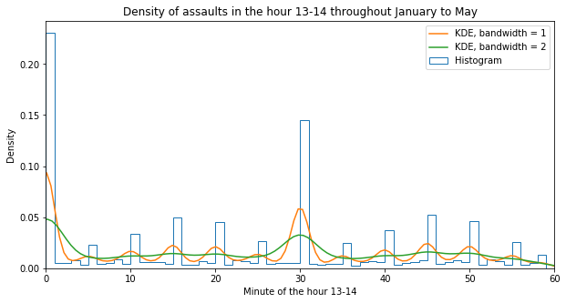

```python
plt.figure(figsize=(10, 5))
histogram(assaults_filtered.Minute, no_of_bins=60, density=True, label='Histogram')
sns.kdeplot(assaults_filtered.Minute, bw=1, label='KDE, bandwidth = 1')
sns.kdeplot(assaults_filtered.Minute, bw=2, label='KDE, bandwidth = 2')
plt.xlabel('Minute of the hour 13-14')
plt.ylabel('Density')
plt.xlim(0, 60)
plt.title('Density of assaults in the hour 13-14 throughout January to May')
plt.show()
```

It is clear from this plot that the KDEs need to have the right bandwidth to represent the true density correctly. In this case a bandwidth of 1 seems to work fairly well. However, a bandwidth of 2 grossly underestimates the true density at the spikes while overestimating outside of the steps. This gives an impression that the distribution is a lot flatter than it actually is.

**Now grab 25 random timepoints from the dataset you've just plotted and create the same Figure 2-4 plot once again, but with fewer points. Does this shed light on why I think KDEs can bee misleading?**

```python
samples_indices = np.random.choice(range(len(assaults_filtered)), size=25, replace=False)
```

```python
assaults_samples = assaults_filtered.iloc[samples_indices]
```

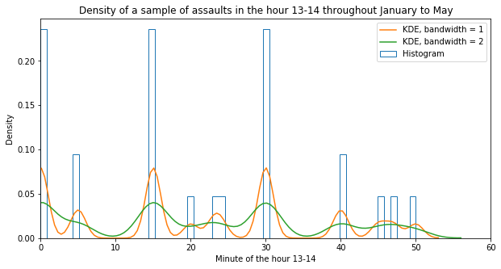

```python
plt.figure(figsize=(10, 5))
histogram(assaults_samples.Minute, no_of_bins=60, density=True, label='Histogram')
sns.kdeplot(assaults_samples.Minute, bw=1, label='KDE, bandwidth = 1')
sns.kdeplot(assaults_samples.Minute, bw=2, label='KDE, bandwidth = 2')
plt.xlabel('Minute of the hour 13-14')
plt.ylabel('Density')
plt.xlim(0, 60)
plt.title('Density of a sample of assaults in the hour 13-14 throughout January to May')
plt.show()
```

It is hard to compare the KDEs with the previous unsampled versions by scrolling up and down between the two plots. Therefore we have created another plot to directly compare the KDEs for the unsampled and samples data (bandwidth = 1).

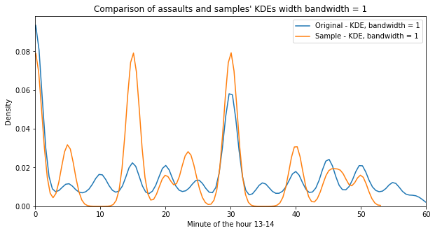

```python
plt.figure(figsize=(10, 5))
sns.kdeplot(assaults_filtered.Minute, bw=1, label='Original - KDE, bandwidth = 1')
sns.kdeplot(assaults_samples.Minute, bw=1, label='Sample - KDE, bandwidth = 1')
plt.xlabel('Minute of the hour 13-14')
plt.ylabel('Density')
plt.xlim(0, 60)
plt.title('Comparison of assaults and samples\' KDEs width bandwidth = 1')
plt.show()
```

**Create your own two versions of Figure 2-11, but using the GPS data you used for your version of Figure 2-2. Comment on the result. It is not easy to create this plot from scracth, bHint: Take a look at the scipy.stats.probplot function.**

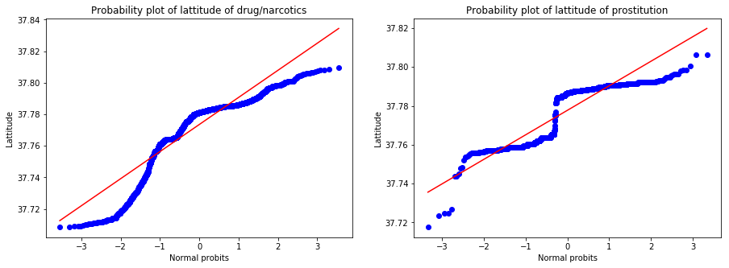

```python
x_drug = stats.norm.rvs(loc=0, scale=1, size=len(drug))
x_prost = stats.norm.rvs(loc=0, scale=1, size=len(prost))

plt.figure(figsize=(15, 5))

plt.subplot(1, 2, 1)
stats.probplot(drug.Y, plot=plt)
plt.xlabel('Normal probits')
plt.ylabel('Lattitude')
plt.title('Probability plot of lattitude of drug/narcotics')

plt.subplot(1, 2, 2)
stats.probplot(prost.Y, plot=plt)
plt.xlabel('Normal probits')
plt.ylabel('Lattitude')
plt.title('Probability plot of lattitude of prostitution')

plt.show()
```

These two plots show us that neither the lattitude of drug/narcotics or prostitution follow a Gaussian distribution. This is not surprising considering the previous plotted histograms of the two variables. For example we previously saw that prostitution has two spikes and the probability plot for prostitution above seems to confirm this finding with the two seemingly straight lines around lattitude = 37.76 and lattitude $\in [37.78, 37.80]$.

**Now box plots. Here, I'd like you to use the box plots to visualize fluctuations of how many crimes happen per day. For the 15 focus crimes defined last week.**

```python
focuscrimes = set(['WEAPON LAWS', 'PROSTITUTION', 'DRIVING UNDER THE INFLUENCE', 'ROBBERY', 'BURGLARY', 'ASSAULT', 'DRUNKENNESS', 'DRUG/NARCOTIC', 'TRESPASS', 'LARCENY/THEFT', 'VANDALISM', 'VEHICLE THEFT', 'STOLEN PROPERTY', 'DISORDERLY CONDUCT'])
```

**For the full time-span of the data, calulate the number of crimes per day within each category for the entire duration of the data (this should result in 15 datasets, on for each focus crime).**

```python
def get_category_date_count(category):
    return data[data.Category == category].groupby('Date')['IncidntNum'].count().to_numpy()

boxplot_data = list(map(get_category_date_count, focuscrimes))
```

**Create a box-and whiskers plot showing the mean, median, quantiles, etc for each of the 15 crime-types and show them side-by-side. There are many ways to do this, I like to use matplotlibs's built in functionality**

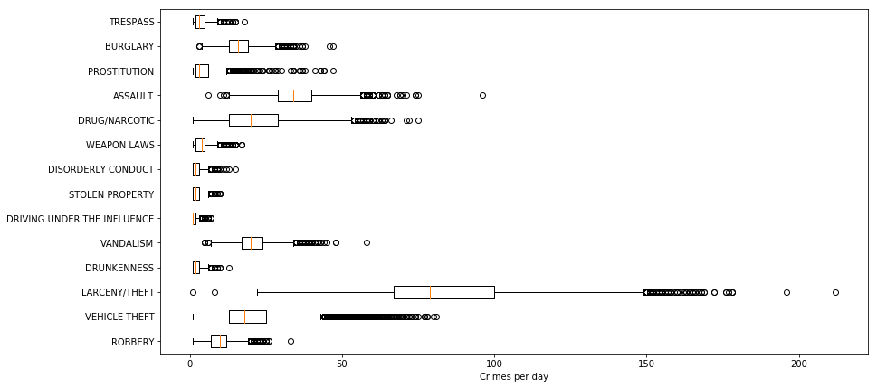

```python
plt.figure(figsize=(14, 7))
plt.boxplot(boxplot_data, labels=focuscrimes, vert=False)
plt.xlabel('Crimes per day')
plt.show()
```

**What does this plot reveal that you can't see in the plots from last time?**

The boxplots show us the same order in the most frequent crimes as for the histograms of focus crimes. E.g. larcency/theft is more frequent than stolen property. In regard to what we can't see in the plots from last time, we also get the variation in each focus crime from the box-and-whiskers plot. An example is that there is a huge variation in larcency/theft as well as e.g. assault. Other focus crimes - such as "driving under the influence" - appear to have little to no variation.

# Part 4: Decision tree (From Week 4)

**The idea for this exercise is to pick two crime-types that have different geographical patterns and different temporal patterns. We can then use various variables of the real crime data as categories to build a decision tree. I'm thinking we can use**

- **`DayOfWeek` (`Sunday`, ..., `Saturday`). (Note: Will need to be encodede as integer in sklearn)**
- **`PD District` (`TENDERLOIN`, etc). (Note: Will need to be encodede as integer in sklearn)**

**And we can extract a few more from the `Time` and `Date` variables**

- **Hour of the day (1-24)**
- **Month of the year (1-12)**

**So your job is to select two crime categories that (based on your analyses from the past three weeks) have different spatio-temporal patterns.**

**Some notes/hints**

- **It is important for your success here to create a balanced dataset, that is, *grab an equal number of examples* from each of the two crime categories. Pick categories with lots of training data. It's probably nice to have something like 10000+ examples of each category to train on.**
- **Also, I recommend you grab your training data at random from the set of all examples, since we want crimes to be distributed equally over time.**

```python
districts = data["PdDistrict"].unique()[:10]
categories = data.groupby(["Category"]).size().sort_values(ascending=False).head(8)
categories
```

```
Category
LARCENY/THEFT     480448
OTHER OFFENSES    309358
NON-CRIMINAL      238323
ASSAULT           194694
VEHICLE THEFT     126602
DRUG/NARCOTIC     119628
VANDALISM         116059
WARRANTS          101379
dtype: int64
```

The categories satisfying the 10.000+ condition are shown above. Extra integer columns are added for `Day`, `Dst` (district category), `Hour` and `Month`.

To find out which two categories would suit the task well, we'll plot crime count against districts and different weekdays.

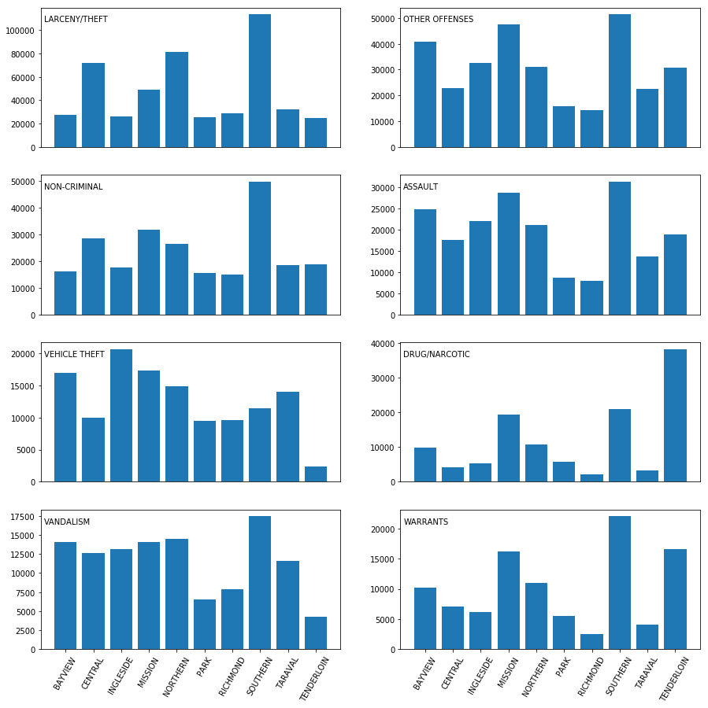

```python
fig = plt.figure(figsize=(15, 15))
pos = np.arange(len(districts))

for i, category in enumerate(categories.keys()):
    ax = plt.subplot(4, 2, i + 1)
    ax.text(.01, .9, category, transform=ax.transAxes)

    displayed = data[data["Category"] == category].groupby(["PdDistrict"]).size()
    plt.bar(pos, displayed, align='center')

    if (i is 6) or (i is 7):
        plt.xticks(pos, displayed.keys(), rotation=60)
    else:
        plt.xticks([])

plt.show()
```

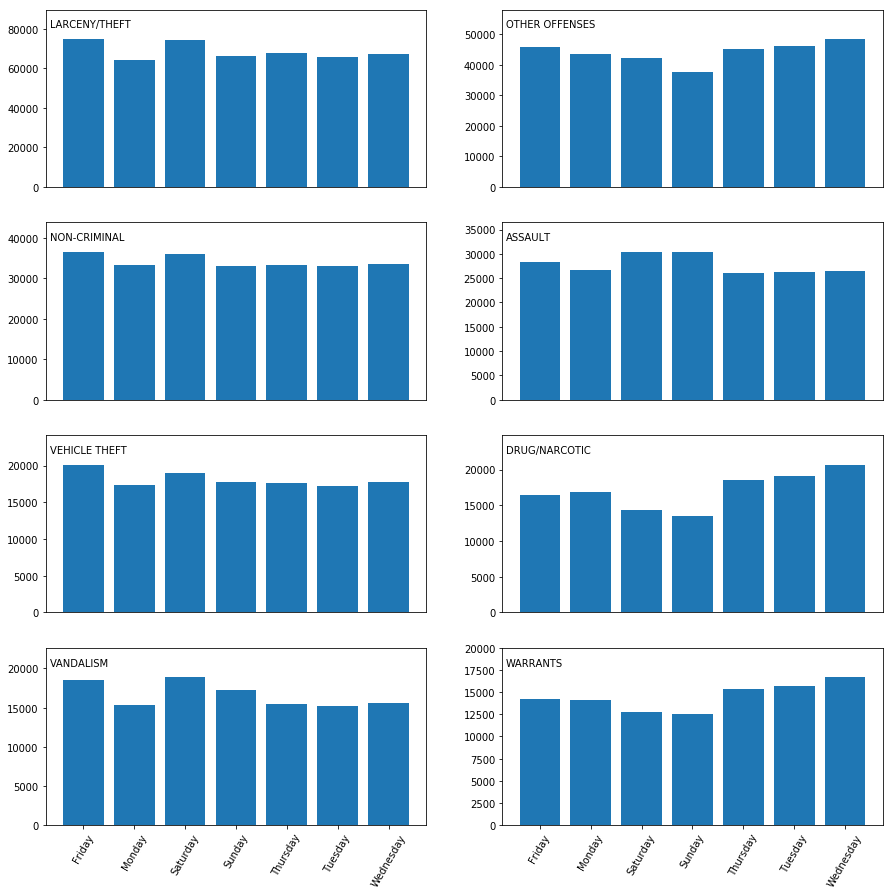

```python
fig = plt.figure(figsize=(15, 15))
pos = np.arange(7)

for i, category in enumerate(categories.keys()):
    ax = plt.subplot(4, 2, i + 1)
    ax.text(.01, .9, category, transform=ax.transAxes)
    ax.margins(y=0.2)

    displayed = data[data["Category"] == category].groupby(["DayOfWeek"]).size()
    plt.bar(pos, displayed, align='center')

    if (i is 6) or (i is 7):
        plt.xticks(pos, displayed.keys(), rotation=60)
    else:
        plt.xticks([])

plt.show()
```

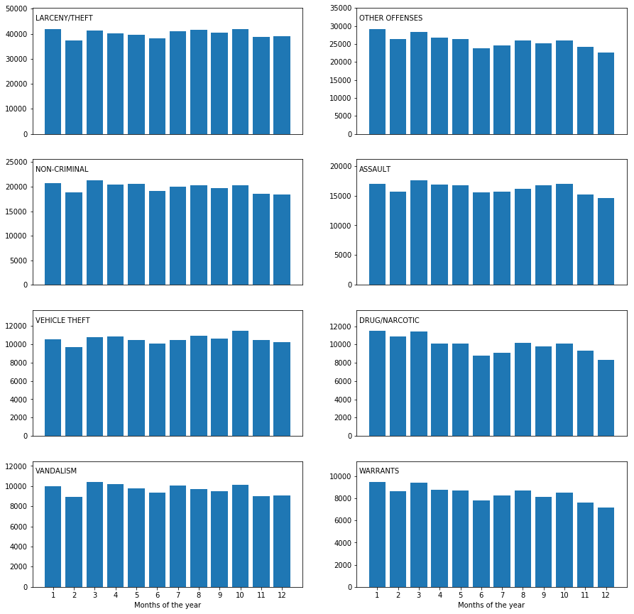

```python
fig = plt.figure(figsize=(15, 15))
pos = np.arange(12)

for i, category in enumerate(categories.keys()):
    ax = plt.subplot(4, 2, i + 1)
    ax.text(.01, .9, category, transform=ax.transAxes)
    ax.margins(y=0.2)

    displayed = data[data["Category"] == category].groupby(["Month"]).size()
    plt.bar(pos, displayed, align='center')

    if (i is 6) or (i is 7):
        plt.xticks(pos, displayed.keys())
        plt.xlabel('Months of the year')
    else:
        plt.xticks([])

plt.show()
```

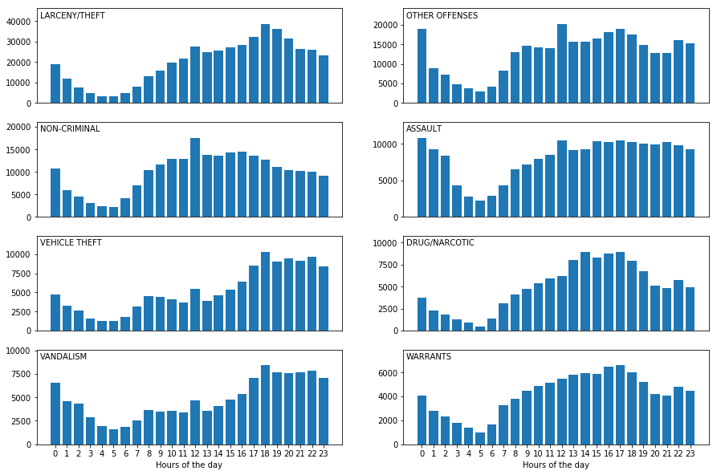

```python
fig = plt.figure(figsize=(15, 10))
pos = np.arange(24)

for i, category in enumerate(categories.keys()):
    ax = plt.subplot(4, 2, i + 1)
    ax.text(.01, .9, category, transform=ax.transAxes)
    ax.margins(y=0.2)

    displayed = data[data["Category"] == category].groupby(["Hour"]).size()
    plt.bar(pos, displayed, align='center')

    if (i is 6) or (i is 7):
        plt.xticks(pos, displayed.keys())
        plt.xlabel('Hours of the day')
    else:
        plt.xticks([])

plt.show()
```

```python
vehicle_data = data[data["Category"] == "VEHICLE THEFT"][["Dst", "Day", "Hour", "Month"]]
vehicle_clean = vehicle_data.sample(frac=1).reset_index(drop=True)
vehicle_train = vehicle_clean[:10000]
vehicle_test = vehicle_clean[10000:11000]

drug_data = data[data["Category"] == "DRUG/NARCOTIC"][["Dst", "Day", "Hour", "Month"]]
drug_clean = drug_data.sample(frac=1).reset_index(drop=True)
drug_train = drug_clean[:10000]
drug_test = drug_clean[10000:11000]

print(vehicle_train.head())
print(drug_train.head())
```

```
   Dst  Day  Hour  Month
0    2    5    18      9
1    2    0     1      5
2    2    4    20      9
3    3    6    16      5
4    4    6    23     12
   Dst  Day  Hour  Month
0    3    6    22      5
1    9    2    13      4
2    3    5    14      5
3    7    4    16      7
4    0    4    15      1
```

The rows are shuffled, and the dataframes are then split into train and test data - with size of 10.000 and 1.000 respectively.

**Then we are going to to build is a decision tree (or a random forest) that takes as input the four labels (Hour-of-the-day, Day-of-the-week, Month-of-the-year, and PD-District) of some crime (from one of the two categories) and then tries to predict which category that crime is from.**

**Some notes/hints**

- **A good option is the DecisionTreeClassifier.**
- **Since you have created a balanced dataset, the baseline performance (random guess) is 50%. How good can your classifier get?**

Now we are ready to train our first model.

```python
X = vehicle_train.append(drug_train)
Y1 = pd.Series(0, index=list(range(10000)))
Y2 = pd.Series(1, index=list(range(10000)))
Y = Y1.append(Y2)

clf = tree.DecisionTreeClassifier()
clf = clf.fit(X, Y)
```

```python
def stats(clf, vehicle_testset, drug_testset):
    n = len(vehicle_testset) + len(drug_testset)
    v_predictions = clf.predict(vehicle_testset)
    d_predictions = clf.predict(drug_testset)
    accuracy = ((v_predictions == 0).sum() + (d_predictions == 1).sum()) / n
    return accuracy
```

```python
stats(clf, vehicle_test, drug_test)
```

```
0.6585
```

With an accuracy around 65% we are not much better than the 50% baseline. This could be improved using different approaches (more data, regularization etc.). We will attempt to improve it with a random forest classifier.

```python
model = RandomForestClassifier(n_estimators=10)
model.fit(X, Y)

stats(model, vehicle_test, drug_test)
```

```
0.6755
```

An accuracy of ~67% is about as good as it gets with default parameters. We will try to tweak the parameters a bit. We are aware that we should use a separate validation set for this task (or apply cross-validation) in order to get a better estimate of the generalization error. However, due to brevity, we will optimize the parameters directly against the testset.

```python
model2 = RandomForestClassifier(n_estimators=100, max_depth=13)
model2.fit(X, Y)

stats(model2, vehicle_test, drug_test)
```

```
0.709
```

By manually tweaking the model parameters, we can bring the accuracy up to around 70%. We could apply more systematic techniques (like grid search or cross-validation) to find the optimal parameters but we will settle for ~70%.